# Reproducible Research: Peer Assessment 1

## Loading and preprocessing the data

```r
library(stats)
getwd()
```

```
## [1] "C:/Users/Pascal/Documents/data/reproducibleresearch/RepData_PeerAssessment1"
```

```r
df<-read.csv(file="activity.csv")
```

## What is mean total number of steps taken per day?

1. Total number of steps taken per day

```r
df1<-na.omit(df)
StepPerDay<-aggregate(df1$steps,by=list(factor(df1$date)),sum)
names(StepPerDay)<-c("Date","Steps")
StepPerDay
```

```
##          Date Steps
## 1  2012-10-02   126
## 2  2012-10-03 11352
## 3  2012-10-04 12116
## 4  2012-10-05 13294
## 5  2012-10-06 15420
## 6  2012-10-07 11015
## 7  2012-10-09 12811
## 8  2012-10-10  9900
## 9  2012-10-11 10304
## 10 2012-10-12 17382
## 11 2012-10-13 12426
## 12 2012-10-14 15098
## 13 2012-10-15 10139
## 14 2012-10-16 15084
```

[output cut: 39 more lines]

2. Histogram of the total number of steps taken each day

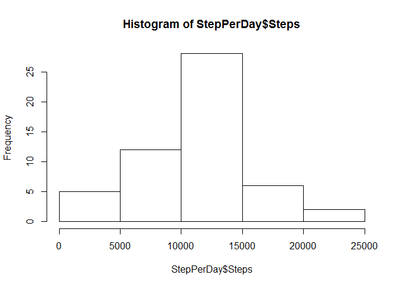

```r
hist(StepPerDay$Steps)
```

3. Mean and median of the total number of steps taken per day

```r
summary(StepPerDay$Steps)[3:4]
```

```
## Median   Mean
##  10760  10770
```

## What is the average daily activity pattern?

1. Time series plot of the 5-minutes interval and the average number of steps taken, averaged across all days

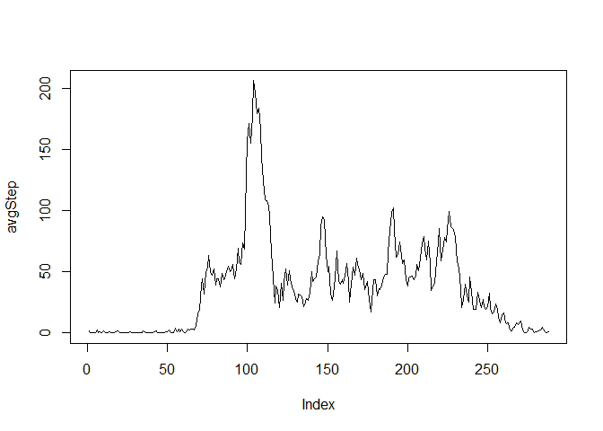

```r
df1$timeinterval<-rep(1:288,53)
avgStep<-tapply(df1$steps,list(df1$timeinterval),mean)
plot(avgStep,type="l")
```

2. 5-minute interval containing the maximum number of steps

The 104th 5-minute interval contains the maximum number of steps

```r
avgStep[avgStep==max(avgStep)]
```

```
##      104
## 206.1698
```

## Imputing missing values

1. Number of rows, which is NA

```r
NROW(df[is.na(df),])
```

```
## [1] 2304
```

There are 8 days where the rows are NA. These days are:

```r
levels(factor(df[is.na(df),]$date))
```

```
## [1] "2012-10-01" "2012-10-08" "2012-11-01" "2012-11-04" "2012-11-09"
## [6] "2012-11-10" "2012-11-14" "2012-11-30"
```

2. Strategy for filling in all of the missing values in the dataset

We will replace the NA value with the 5-minutes interval average number of steps taken, averaged across all days.

3. Create a new data set that is equal to the original dataset but with the missing data filled in We create the df2 dataset.

```r
df2<-df
df2[df2$date %in% levels(factor(df2[is.na(df),]$date)),]$steps<-rep(avgStep,8)
```

4. Histogram of the total number of steps taken each day. Means and median. Histogram

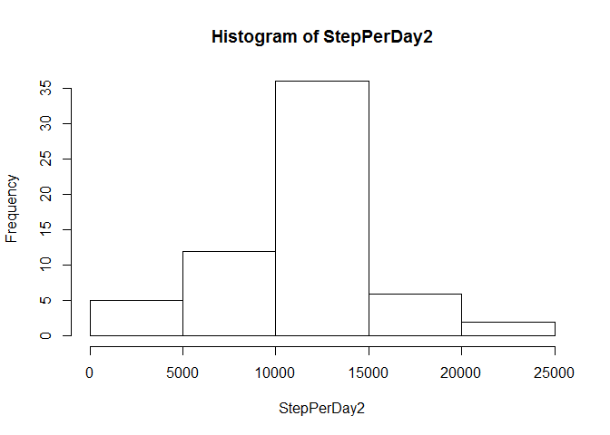

```r
StepPerDay2<-tapply(df2$steps,df2$date,sum)

hist(StepPerDay2)
```

Means and Median

```r
summary(StepPerDay2)[3:4]
```

```
## Median   Mean
##  10770  10770
```

## Are there differences in activity patterns between weekdays and weekends?

1. Newfactor variable indicating whether a given date is a weekday or a weekdate

The new variable is daytype

```r
df2$weekday<-weekdays(as.Date(df2$date))
df2$daytype<-"weekday"
df2[df2$weekday == "Sunday" | df2$weekday == "Saturday",]$daytype<-"weekend"
df2$daytype<-as.factor(df2$daytype)
```

2. Panel plot comparing the number of steps weekday and weekend

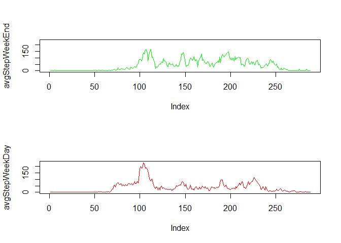

```r
df2$timeinterval<-rep(1:288,61)
df2weekend<-df2[df2$daytype=="weekend",]
df2weekday<-df2[df2$daytype=="weekday",]
avgStepWeekEnd<-tapply(df2weekend$steps,list(df2weekend$timeinterval),mean)
avgStepWeekDay<-tapply(df2weekday$steps,list(df2weekday$timeinterval),mean)
rng<-range(avgStepWeekDay,avgStepWeekEnd)
par(mfrow=c(2,1))
plot(avgStepWeekEnd,type="l",col="green",ylim=rng)
plot(avgStepWeekDay,type="l",col="red",ylim=rng)
```